# PA1_template.Rmd

Rostislav Caha

5.9.2020

# Peer-graded Assignment: Course Project 1

## Activity monitoring devices

### (1) get data

```r
if(!file.exists("repdata data activity.zip")) {
      download.file("https://d396qusza40orc.cloudfront.net/repdata%2Fdata%2Factivity.zip","repdata data activity.zip")
}
unzip("repdata data activity.zip")
data <- read.csv("activity.csv")
```

### (2) Histogram of the total number of steps taken each day

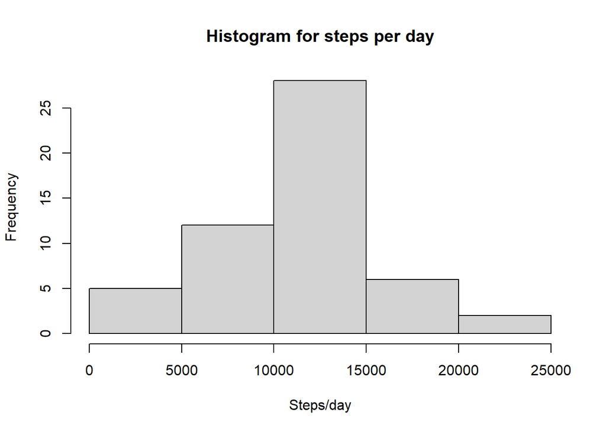

```r
daily_sum <- aggregate(steps~date,data=data,na.rm=TRUE,sum)

hist(daily_sum$steps,xlab="Steps/day",main="Histogram for steps per day")
```

### (3) Mean and median number of steps taken each day

```r
mean_steps <- mean(daily_sum$steps)
median_steps <- median(daily_sum$steps)
```

Mean for numbers of steps per day is 10766.19 and median is 10765.

### (4) Time series plot of the average number of steps taken

```r
interval_average <- aggregate(steps~interval,data=data,na.rm=TRUE,mean)
wm <- which.max(interval_average$steps)
interval_average$steps[wm]
```

```
## [1] 206.1698
```

```r
interval_average$interval[wm]
```

```
## [1] 835
```

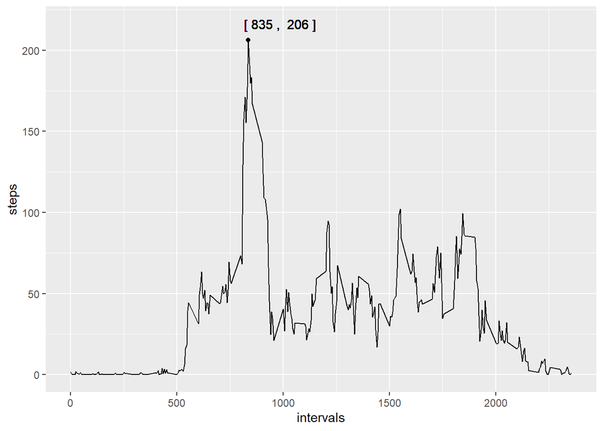

```r
library("ggplot2")
p <- ggplot(interval_average, aes(x=interval, y=steps)) +
      geom_line() +
      xlab("intervals")+geom_point(aes(x=interval[wm], y=steps[wm]))+geom_text(aes(x=interval[wm]+150, y=steps[wm]+10,label=paste("[",interval[wm],", ",round(steps[wm]),"]")))
p
```

### (5) The 5-minute interval that, on average, contains the maximum number of steps

```r
interval_average <- aggregate(steps~interval,data=data,na.rm=TRUE,mean)
wm <- which.max(interval_average$steps)
interval_average$steps[wm]
```

```
## [1] 206.1698
```

```r
interval_average$interval[wm]
```

```
## [1] 835
```

Maximal value is 206.17 step for the interval 835.

### (6) Code to describe and show a strategy for imputing missing data

I have taken into account two strategies for imputing missing values:

1. not to change interval mean: we will replace each missing value for the mean of the corresponding interval. It means, that the mean of the interval over whole time will not change. The reason - we can expect, that the behavior of the person will be the same across the long term period.
2. the similar to 1. - instead of mean we can use median which do not change medians of the corresponding interval over the whole period

As global median and mean is very similar (difference = 1.19), so the approaches are almost equivalent. I will use the case 1.

```r
library("dplyr")
data_imp <- merge(x=data,y=interval_average, by="interval")
NAs <- is.na(data_imp$steps.x)
data_imp$steps.x[NAs]<-data_imp$steps.y[NAs]
data_imp <- data_imp %>% mutate(steps=steps.x)
```

In the original data there was 2304 rows with NA. Those were replaced by mean of the corresponding interval.

### (7) Histogram of the total number of steps taken each day after missing values are imputed

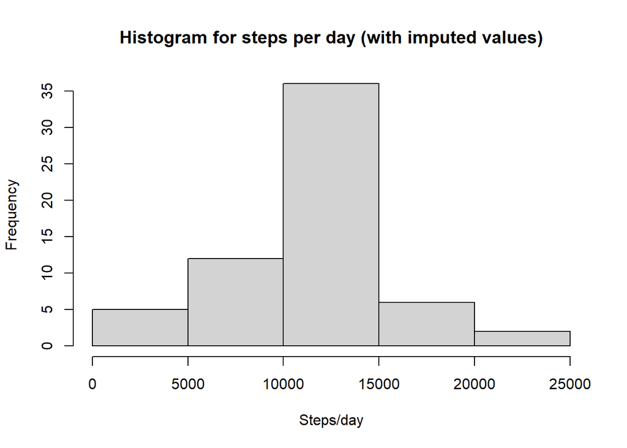

```r
daily_sum_imp <- aggregate(steps~date,data=data_imp,sum)

hist(daily_sum_imp$steps,xlab="Steps/day",main="Histogram for steps per day (with imputed values)")
```

### (8) Panel plot comparing the average number of steps taken per 5-minute interval across weekdays and weekends

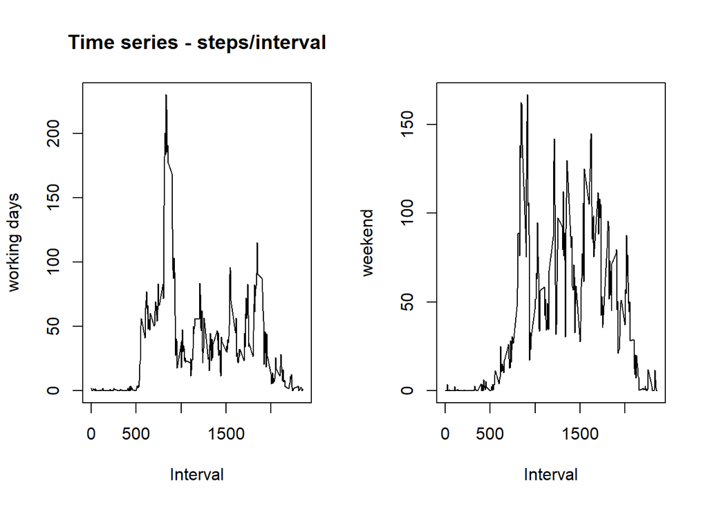

```r
library("dplyr")

data_imp <- data_imp %>% mutate(working=(as.POSIXlt(date)$wday>0 & as.POSIXlt(date)$wday<6))
interval_weekdays_average <- aggregate(steps~interval+working,data=data_imp,mean)

par(mfrow=c(1,2))
plot(type="l", x=interval_weekdays_average$interval[interval_weekdays_average$working], y=interval_weekdays_average$steps[interval_weekdays_average$working],xlab="Interval",ylab="working days",main="Time series - steps/interval")
plot(type="l", x=interval_weekdays_average$interval[!interval_weekdays_average$working], y=interval_weekdays_average$steps[!interval_weekdays_average$working],xlab="Interval",ylab="weekend")
```

### (9) All of the R code needed to reproduce the results (numbers, plots, etc.) in the report

DONE :)

### Cleaning house

```r
rm(data,
      daily_sum,
      mean_steps,median_steps,
      interval_average, wm, p,
      data_imp, NAs,
      daily_sum_imp,
      interval_weekdays_average
   )
```